# Recommendation System

Archit Gupta

September 6, 2016

**Recommendation systems**, also referred to as recommender systems, often rely on the notion of similarity between objects, in an approach known as collaborative filtering. Its basic premise is that customers can be considered similar to each other if they share most of the products that they have purchased; equally, items can be considered similar to each other if they share a large number of customers who purchased them.

There are a number of different ways to quantify this notion of similarity, and we will present some of the commonly used alternatives. Whether we want to recommend movies, books, hotels, or restaurants, building a recommender system often involves dealing with very large data sets.

### Rating matrix

A recommendation system usually involves having a set of users U = {u1, u2, ., um} that have varying preferences on a set of items I = {i1, i2, ., in}. The number of users |U| = m is different from the number of items |I| = n in the general case. In addition, users can often express their preference by rating items on some scale. As an example, we can think of the users as being restaurant patrons in a city, and the items being the restaurants that they visit. Under this setup, the preferences of the users could be expressed as ratings on a five star scale. Of course, our generalization does not require that the items be physical items or that the users be actual people-this is simply an abstraction for the recommender system problem that is commonly used.

Let’s return to our example of a restaurant recommender system and build some example data. A natural data structure that is popularly used for recommendation systems is the rating matrix. This is an m × n matrix where the rows represent the users and the columns represent the items. Each entry, ei,j, of the matrix represents the rating made by the user i for item j. What follows is a simple example:

```r
oliver <- c(1,1,2,5,7,8,9,7)
thibault <- c(5,9,4,1,1,7,5,9)
maria <- c(1,4,2,5,8,6,2,8)
pedro <- c(2,6,7,2,6,1,8,9)
ines <- c(1,3,2,4,8,9,7,7)
gertrude <- c(1,6,5,7,3,2,5,5)

ratingMatrix <- rbind(oliver, thibault, maria, pedro, ines, gertrude)

colnames(ratingMatrix) <- c("Berny's", "La Traviata", "El Pollo Loco", "Joey's Pizza", "The Old West", "Jake and Jill", "Full Moon", "Acropolis")

ratingMatrix
```

```
##          Berny's La Traviata El Pollo Loco Joey's Pizza The Old West Jake and Jill Full Moon Acropolis
## oliver         1           1             2            5            7             8         9         7
## thibault       5           9             4            1            1             7         5         9
## maria          1           4             2            5            8             6         2         8
## pedro          2           6             7            2            6             1         8         9
## ines           1           3             2            4            8             9         7         7
## gertrude       1           6             5            7            3             2         5         5
```

Here, we have used a 10-point scale as a rating system, where 10 is the highest rating and 1 is the lowest.

Concretely, suppose that a new user, Silvan, has rated a few restaurants and we would like to make a recommendation for a suitable restaurant to which he has not been. Alternatively, we might want to propose a list of top three restaurants or even predict whether Silvan will like a specific restaurant he is currently considering.

One way to think about this problem is to find users that have similar views as Silvan on the restaurants that he has already rated. Then, we could use their ratings on restaurants that Silvan has not yet rated in order to predict Silvan’s rating for those restaurants. This seems promising, but we should first think about how we might quantify this notion of similarity between two users based on their item ratings.

### Measuring user similarity

Even with a very large database of users, chances are that for a real-world recommender system, it will be rare-if not massively unlikely-to find two people that would rate all the items in our item set with the exact same score. That being said, we can still say that some users are more similar than others based on how they rate different items. For example, in our restaurant rating matrix, we can see that Ines and Oliver rated the first four restaurants poorly and the last four restaurants highly and so their tastes can be considered far more similar compared to a pair like Thibault and Pedro, who sometimes agree and sometimes have completely opposite views on a particular restaurant.

By representing a user as their particular row in the rating matrix, we can think of a user as being a vector in an n dimensional space, n being the number of items. Thus we can use different distance measures appropriate for vectors in order to measure the similarity of two different users. Note that the notion of distance is inversely proportional to the notion of similarity and we can thus use measures of distance as measures of similarity by interpreting a large distance between two vectors as analogous to a low similarity score.

The most familiar distance metric for two vectors a and b is the Euclidean distance. We can use R’s built-in dist() function to compute all the pair-wise distances in our rating matrix as follows:

```r
dist(ratingMatrix, method = 'euclidean')
```

```
##             oliver  thibault     maria     pedro      ines
## thibault 12.529964
## maria     8.000000 11.000000
## pedro    10.723805  9.899495 10.246951
## ines      3.316625 11.224972  6.082763 10.583005
## gertrude 10.488088 10.344080  8.717798  8.062258 10.440307
```

The result is a lower triangular matrix because the Euclidean distance is a symmetric function. Thus, the entry for (maria, pedro) is exactly the same as for (pedro, maria) and so we only need to display one of these. Here, we can explicitly see that Ines and Oliver are the two most similar users as the distance between them is smallest.Note that we can also talk about the distances between items in terms of the similarity of the ratings they received from different users. All we have to do to compute this is to transpose the rating matrix:

```r
dist(t(ratingMatrix), method = 'euclidean')
```

```
##                 Berny's La Traviata El Pollo Loco Joey's Pizza The Old West Jake and Jill Full Moon
## La Traviata    8.366600
## El Pollo Loco  6.708204    5.744563
## Joey's Pizza   9.643651    9.949874      7.745967
## The Old West  13.038405   12.247449     10.535654     7.810250
## Jake and Jill 12.000000   11.575837     12.449900     9.848858     8.246211
## Full Moon     12.369317   10.246951      8.717798     9.486833     8.062258      9.110434
## Acropolis     14.212670    8.831761     10.723805    11.789826     8.831761      9.273618  7.549834
```

As we can see, the two most dissimilar restaurants (that is to say, those with the largest difference between them) are the Acropolis and Berny’s. Looking back at the rating matrix, we should easily convince ourselves why this is the case. The former restaurant has received largely positive reviews across our user base whereas the reviews have been poor for the latter.

A commonly used alternative to the Euclidean distance (or L2 norm, as it is also known) is the cosine distance. This metric measures the cosine of the smallest angle between two vectors. If the vectors are parallel to each other, meaning that their angle is 0, then the cosine distance is 0 as well. If the two vectors are at a right angle to each other, then they have the largest distance according to this metric.

```r
library("proxy")
dist(ratingMatrix, method = 'cosine')
```

```
##              oliver   thibault      maria      pedro       ines
## thibault 0.28387670
## maria    0.12450495 0.23879093
## pedro    0.20947046 0.17687385 0.20854178
## ines     0.02010805 0.22821528 0.06911870 0.20437426
## gertrude 0.22600742 0.21481973 0.19156876 0.12227138 0.22459114
```

Suppose instead that our users rated restaurants on a binary scale. We can convert our rating matrix into a binary rating matrix by considering all ratings above 5 to be positive and assigning them a new score of 1. The remaining ratings are all converted to a score of 0. For two binary vectors, the Jaccard similarity is given by the cardinality of the logical intersection divided by the cardinality of the logical union.

```r
binaryRatingMatrix <- ratingMatrix > 5
dist(binaryRatingMatrix, method = 'jaccard')
```

```
##             oliver  thibault     maria     pedro      ines
## thibault 0.6000000
## maria    0.2500000 0.5000000
## pedro    0.5000000 0.6666667 0.6666667
## ines     0.0000000 0.6000000 0.2500000 0.5000000
## gertrude 1.0000000 0.7500000 1.0000000 0.8333333 1.0000000
```

## Collaborative filtering

There are two very common variants of collaborative filtering, memory-based collaborative filtering and model-based collaborative filtering. With memory-based collaborative filtering, the entire history of all the ratings made by all the users is remembered and must be processed in order to make a recommendation. The prototypical memory-based collaborative filtering method is user-based collaborative filtering. Although this approach uses all the ratings available, the downside is that it can be computationally expensive as the entire database is used in order to make rating predictions for our test user.

The alternative approach to this is embodied in model-based collaborative filtering. Here, we first create a model of the rating preferences of our users, such as a set of clusters of users who like similar items, and then use the model to generate recommendations. We will study item-based collaborative filtering, which is the most well-known model-based collaborative filtering method.

### User-based collaborative filtering

User-based collaborative filtering is commonly described as a memory-based or lazy learning approach.in user-based collaborative filtering, when we want to make recommendations for a new user, we will first pick a set of similar users using a particular distance metric. Then, we try to infer the ratings that our target user would assign to items that he or she has not yet rated as an average of the ratings made by these similar users on those items. We usually refer to this set of similar users as the user’s neighborhood. Thus, the idea is that a user will prefer items that their neighborhood prefers.

Typically, there are two ways to define the user’s neighborhood. We can compute a fixed neighborhood by finding the k-nearest neighbors. These are the k users in our database that have the smallest distance between them and our target user.

Alternatively, we can specify a similarity threshold and pick all the users in our database whose distance from our target user does not exceed this threshold. This second approach has the advantage that we will be making recommendations using users that are as close to our target user as we want, and therefore our confidence in our recommendation can be high. On the other hand, there might be very few users that satisfy our requirement, meaning that we will be relying on the recommendations of these few users. Worse, there might be no users in our database who are sufficiently similar to our target user and we might not be able to actually make a recommendation at all. If we don’t mind our method sometimes failing to make a recommendation, for example because we have a backup plan to handle these cases, the second approach might be a good choice.

Another important consideration to make in a real-world setting is the problem of sparse ratings. In our simple restaurant example, every user had rated every restaurant. This rarely happens in a real situation, if ever, simply because the number of items is usually too big for a user to rate them all. If we think of e-commerce websites such as amazon.com, for example, it is easy to imagine that the most products that any user has rated is still only a small fraction of the overall number of products on sale.

Once we have decided on a distance metric and how to form a neighborhood of users that are similar to our test user, we then use this neighborhood to compute the missing ratings for the test user. The easiest way to do this is to simply compute the average rating for each item in the user neighborhood and report this value.

A first possible improvement comes from the observation that some users will tend to consistently rate items more strictly or more leniently than other users, and we would like to smooth out this variation. In practice, we often use Z-score normalization, which takes into account the variance of the ratings. We can also center each rating made by a user by subtracting that user’s average rating across all the items. In the rating matrix, this means subtracting the mean of each row from the elements of the row. Let’s apply this last transformation to our restaurant rating matrix and see the results:

```r
centered_rm <- t(apply(ratingMatrix, 1, function(x) x - mean(x)))
centered_rm
```

```
##          Berny's La Traviata El Pollo Loco Joey's Pizza The Old West Jake and Jill Full Moon Acropolis
## oliver    -4.000      -4.000        -3.000        0.000        2.000         3.000     4.000     2.000
## thibault  -0.125       3.875        -1.125       -4.125       -4.125         1.875    -0.125     3.875
## maria     -3.500      -0.500        -2.500        0.500        3.500         1.500    -2.500     3.500
## pedro     -3.125       0.875         1.875       -3.125        0.875        -4.125     2.875     3.875
## ines      -4.125      -2.125        -3.125       -1.125        2.875         3.875     1.875     1.875
## gertrude  -3.250       1.750         0.750        2.750       -1.250        -2.250     0.750     0.750
```

Other reasons why we might want to incorporate weights in the ratings made by other users include trust. For example, we might trust a user that has been using our restaurant recommendation service for a long time more than a more recent user. Equally, we might also want to consider the total number of items that a user has rated in common with the new user. For example, if a user has only rated two items in common with the new user, then even if the corresponding ratings made are identical, the evidence that these two users are indeed very similar is little.

### Item-based collaborative filtering

Item-based collaborative filtering is a model-based approach to collaborative filtering. The central idea underlying this method is that instead of looking at other users similar to the test user, we will directly recommend items that are similar to the items that have received a high rating by the test user. As we are directly comparing items instead of first comparing users in order to recommend items, we can build up a model to describe the similarity of items and then use the model rather than the entire database to make recommendations.

The process of building an item-based similarity model involves computing a similarity matrix for all pairs of items in our database. If we have N items, then we will end up with a similarity matrix with N2 elements in total. To reduce the size of our model, we can store a list of the similarity values of the top k most similar items for every item in the database.

As k will be far smaller than N, we will have a very substantial reduction in the size of the data that we need to keep for our model. For every item in our database, this list of the k most similar items is analogous to the neighborhood of users for the user-based collaborative filtering approach. The same discussion regarding normalizing with respect to the bias and variance of user ratings in user-based collaborative filtering can be applied here. That is, we can compute item-to-item similarities after we normalize our rating matrix.

## Singular value decomposition

SVD is a matrix factorization technique that has a number of useful applications, one of which is dimensionality reduction. It is related to the PCA method of dimensionality reduction.

**SVD** is a matrix factorization process, so we start with an original matrix representing our data and express this as a product of matrices. In a dimensionality reduction scenario, our input data matrix would be the matrix where the rows are data points and the columns are the features; thus, in R, this would just be a data frame. In our recommender systems scenario, the matrix we use is our rating matrix.

We can easily perform SVD on a matrix in R via the svd() function, which is available with R’s base package. Let’s see this with our existing ratingMatrix from before:

```r
options(digits = 2)
(rm_svd <- svd(ratingMatrix))
```

```
## $d
## [1] 35.6 10.6  7.5  5.7  4.7  1.3
##
## $u
##       [,1]  [,2]   [,3]   [,4]   [,5]   [,6]
## [1,] -0.44  0.48 -0.043 -0.401  0.315  0.564
## [2,] -0.41 -0.56  0.703 -0.061  0.114  0.099
## [3,] -0.38  0.24  0.062  0.689 -0.494  0.273
## [4,] -0.43 -0.40 -0.521 -0.387 -0.483 -0.033
## [5,] -0.44  0.42  0.170 -0.108 -0.003 -0.764
## [6,] -0.33 -0.26 -0.447  0.447  0.641 -0.114
##
## $v
##       [,1]   [,2]  [,3]    [,4]   [,5]   [,6]
## [1,] -0.13 -0.255  0.30 -0.0790  0.013  0.301
## [2,] -0.33 -0.591  0.16  0.3234  0.065 -0.486
## [3,] -0.25 -0.382 -0.36 -0.0625 -0.017 -0.200
## [4,] -0.27  0.199 -0.36  0.5796  0.578  0.284
## [5,] -0.38  0.460 -0.30  0.1412 -0.556 -0.325
## [6,] -0.39  0.401  0.68  0.0073  0.239 -0.226
## [7,] -0.42  0.044 -0.26 -0.7270  0.369 -0.047
## [8,] -0.52 -0.161  0.11  0.0279 -0.398  0.628
```

The singular values are returned as a vector d, from which we can easily construct the diagonal matrix using the diag() function. To verify that this factorization really is the correct one that we expected, we can reconstruct our original rating matrix by simply multiplying the matrix factors that we have obtained:

```r
reconstructed_rm <- rm_svd$u %*% diag(rm_svd$d) %*% t(rm_svd$v)
reconstructed_rm
```

```
##      [,1] [,2] [,3] [,4] [,5] [,6] [,7] [,8]
## [1,]    1    1    2    5    7    8    9    7
## [2,]    5    9    4    1    1    7    5    9
## [3,]    1    4    2    5    8    6    2    8
## [4,]    2    6    7    2    6    1    8    9
## [5,]    1    3    2    4    8    9    7    7
## [6,]    1    6    5    7    3    2    5    5
```

One thing to note here is that if we were to attempt a direct equality check with our original matrix, we will most likely fail. This is due to rounding errors that are introduced when we store the factorized matrices. We can check that our two matrices are very nearly equal using the all.equal() function:

```r
all.equal(ratingMatrix, reconstructed_rm, tolerance = 0.000001, check.attributes = F)
```

```
## [1] TRUE
```

Now, once we have this factorization, let’s investigate our singular values. The first singular value of 35.6 is many times larger than the smallest singular value of 1.3.

We can perform dimensionality reduction by keeping the top singular values and throwing the rest away. To do this, we’d like to know how many singular values we should keep and how many we should discard. One approach to this problem is to compute the square of the singular values, which can be thought of as the vector of matrix energy, and then pick the top singular values that preserve at least 90 percent of the overall energy of the original matrix. This is easy to do with R as we can use the cumsum() function for creating a cumulative sum and the singular values are already ordered from largest to smallest:

```r
energy <- rm_svd$d ^ 2
cumsum(energy) / sum(energy)
```

```
## [1] 0.85 0.92 0.96 0.98 1.00 1.00
```

Keeping the first two singular values will retain 92 percent of the energy of our original matrix. Using just two values, we can reconstruct our rating matrix and observe the differences:

```r
d92 <- c(rm_svd$d[1:2], rep(0, length(rm_svd$d) - 2))
reconstructed92_rm <- rm_svd$u %*% diag(d92) %*% t(rm_svd$v)
reconstructed92_rm
```

```
##      [,1] [,2] [,3] [,4] [,5] [,6] [,7] [,8]
## [1,] 0.68  2.0  1.9  5.1  8.3  8.0  6.7  7.2
## [2,] 3.37  8.3  5.9  2.7  2.9  3.3  5.9  8.6
## [3,] 1.10  3.0  2.4  4.1  6.4  6.3  5.9  6.7
## [4,] 3.02  7.5  5.4  3.2  3.9  4.2  6.2  8.6
## [5,] 0.87  2.5  2.2  5.1  8.1  7.9  6.8  7.5
## [6,] 2.20  5.5  4.0  2.6  3.3  3.5  4.9  6.6
```

As we can see there are a few differences in the absolute values, but most of the patterns of different users have been retained to a large extent. Discarding singular values effectively introduces zeros in the leading diagonal of matrix D in the factorization so that this matrix ends up with entire rows and columns that only contain zeros.

## UseCase: Predicting recommendations for movies

The data set can be found at http://grouplens.org/datasets/movielens/. This website contains data on user ratings for movies that were made on the MovieLens website at http://movielens.org. Again, there is more than one data set on the website; we will use the one labeled MovieLens 1M. This contains ratings on a five-point scale (1-5) made by 6,040 users on 3,706 movies. The minimum number of movie ratings per user is 20.

### Loading and preprocessing the data

Downloading the MovieLens 1M archive and unzipping reveals three main data files. The users.dat file contains background information about the users, such as age and gender. The movies.dat data file, in turn, contains information about the movies being rated, namely the title and a list of genres (for example, comedy) to which the movie belongs.The ratings.dat file, contains the ratings themselves.

```r
library(recommenderlab)
movies <- fread(file.path(path2data,"ratings.dat"), sep = ":", header = F)
movies[, c("V2", "V4", "V6", "V7") := NULL]
head(movies)
```

```
##    V1   V3 V5
## 1:  1 1193  5
## 2:  1  661  3
## 3:  1  914  3
## 4:  1 3408  4
## 5:  1 2355  5
## 6:  1 1197  3
```

As we can see, we are now left with three columns, where the first is the UserID, the second is the MovieID, and the last is the rating.

```r
userid_factor <- as.factor(movies[, V1])
movieid_factor <- as.factor(movies[, V3])
movies_sm <- sparseMatrix(i = as.numeric(userid_factor), j = as.numeric(movieid_factor), x = as.numeric(movies[,V5]))
movies_rrm <- new("realRatingMatrix", data = movies_sm)
colnames(movies_rrm) <- levels(movieid_factor)
rownames(movies_rrm) <- levels(userid_factor)
dim(movies_rrm)
```

```
## [1] 6040 3706
```

### Exploring the data

we can make use of the getRatings() function to retrieve the ratings from a rating matrix. This is useful in order to construct a histogram of item ratings. Additionally, we can also normalize the ratings with respect to each user. The following code snippet shows how we can compute ratings and normalized ratings for the MovieLens data and produce histograms for the ratings:

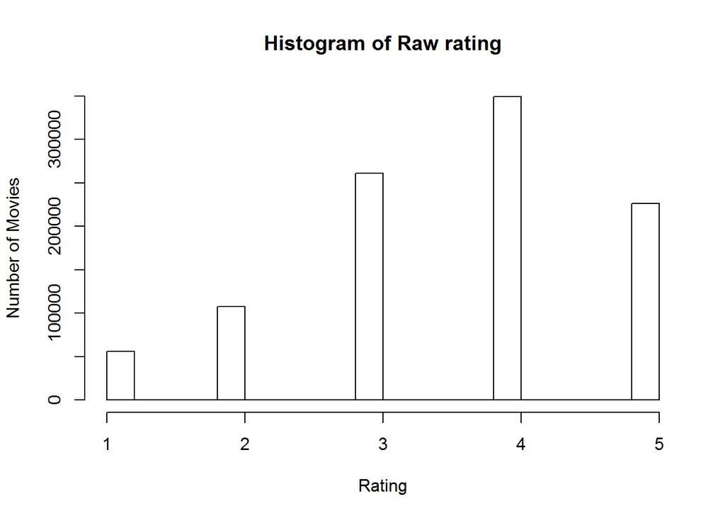

```r
movies_ratings <- getRatings(movies_rrm)
movies_normalized_ratings <- getRatings(normalize(movies_rrm, method = "Z-score"))
hist(movies_ratings, ylab = "Number of Movies", xlab = "Rating", main = "Histogram of Raw rating")
```

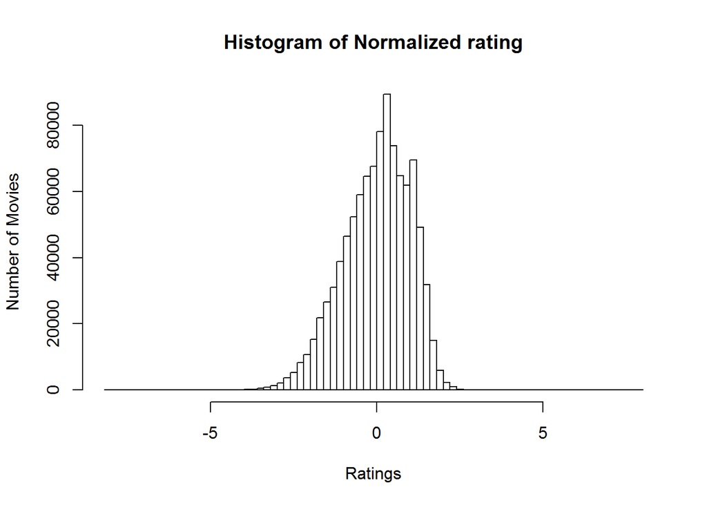

```r
hist(movies_normalized_ratings, ylab = "Number of Movies",xlab = "Ratings", main = "Histogram of Normalized rating", breaks = 100)
```

For the MovieLens data with the 5-point rating scale, 4 is the most prominent rating and higher ratings are far more common than low ratings.

We can also look for the distribution of the number of items rated per user and the average rating per item by looking at the row counts and the column means of the rating matrix respectively.

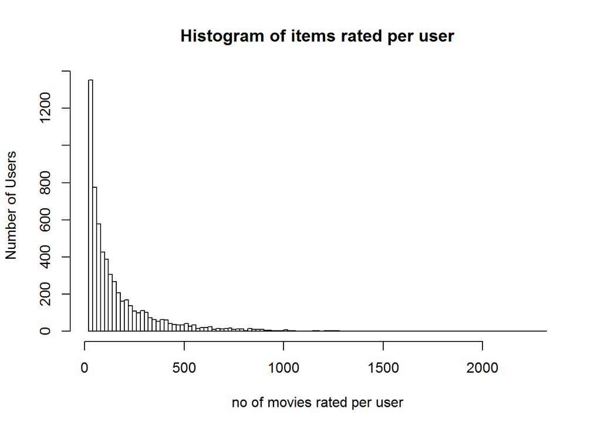

```r
movies_items_rated_per_user <- rowCounts(movies_rrm)
movies_average_item_rating_per_item <- colMeans(movies_rrm)
hist(movies_items_rated_per_user, breaks = 100,xlab = "no of movies rated per user", ylab = "Number of Users", main = "Histogram of items rated per user")
```

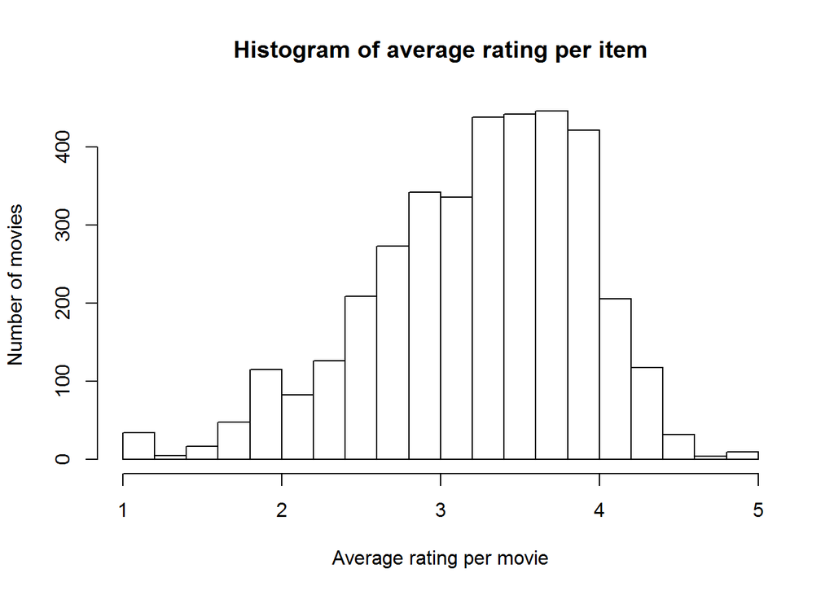

```r
hist(movies_average_item_rating_per_item, breaks = 15, main = "Histogram of average rating per item", ylab = "Number of movies" , xlab = "Average rating per movie")
```

Most of the users have rated very few items, but a small number of very committed users have actually rated a very large number of items.

We can find the average of these distributions in order to determine the average number of items rated per user and the average rating of each item.

```r
(movies_avg_items_rated_per_user <- mean(rowCounts(movies_rrm)))
```

```
## [1] 166
```

```r
(movies_avg_item_rating <- mean(colMeans(movies_rrm)))
```

```
## [1] 3.2
```

### Evaluating binary top-N recommendations

```r
movies_bn <- binarize(movies_rrm, minRating = 3)
movies_bn <- movies_bn[rowCounts(movies_bn) > 1]
dim(movies_bn)
```

```
## [1] 6038 3706
```

The process of training and evaluating multiple algorithms for top-N recommendations begins by creating a list containing the definitions of the algorithms that we want to use. Each element in the list is given a name of our choice but must itself be a list containing a set of parameters for configuring a known algorithm. Concretely, the name parameter of this inner parameter list must be one that the recommenderlab package recognizes.

```r
algorithms <- list(
"Random" = list(name = "RANDOM", param = NULL),
"Popular" = list(name = "POPULAR", param = NULL),
"UserBasedCF_COS" = list(name = "UBCF",param = list(method = "Cosine", nn = 50)),
"UserBasedCF_JAC" = list(name = "UBCF",param = list(method = "Jaccard", nn = 50))
)
```

The RANDOM algorithm is a baseline algorithm that makes recommendations randomly. The POPULAR algorithm is another baseline algorithm that can sometimes be tough to beat. This proposes items in descending order of global popularity, so that for a top-1 recommendation, it will recommend the item with the highest average rating in the data set. We have chosen to try out two variants of user-based collaborative filtering for this example. The first one uses the cosine distance and specifies 50 as the number of nearest neighbors to use. The second one is identical but uses the Jaccard distance instead.

```r
movies_split_scheme <- evaluationScheme(movies_bn, method = "split", train = 0.8,  k = 1, given = 1)
```

```r
movies_split_eval <- evaluate(movies_split_scheme, algorithms, n = 1 : 20)
```

```
## RANDOM run fold/sample [model time/prediction time]
##   1  [0.01sec/14sec]
## POPULAR run fold/sample [model time/prediction time]
##   1  [0.03sec/7.6sec]
## UBCF run fold/sample [model time/prediction time]
##   1  [0.02sec/68sec]
## UBCF run fold/sample [model time/prediction time]
##   1  [0sec/61sec]
```

We now have a list of four objects that represent the evaluation results of each algorithm on our data. We can get important measures such as precision by looking at the confusion matrices. Note that as we have run this experiment for top-N recommendations where N is in the range 1-20, we expect to have 20 such confusion matrices for each algorithm. The function getConfusionMatrix(), when applied to one of these objects, can be used to retrieve the folded confusion matrices in tabular format so that each row represents the confusion matrix for a particular value of N:

```r
options(digits = 4)
getConfusionMatrix(movies_split_eval[[4]])
```

```
## [[1]]
##        TP      FP    FN   TN precision  recall     TPR       FPR
## 1  0.6134  0.3866 143.1 3561    0.6134 0.00874 0.00874 0.0001070
## 2  1.1639  0.8361 142.5 3560    0.5820 0.01605 0.01605 0.0002316
## 3  1.6879  1.3121 142.0 3560    0.5626 0.02323 0.02323 0.0003636
## 4  2.1887  1.8113 141.5 3559    0.5472 0.02985 0.02985 0.0005022
## 5  2.6598  2.3402 141.0 3559    0.5320 0.03568 0.03568 0.0006486
## 6  3.1333  2.8667 140.6 3558    0.5222 0.04165 0.04165 0.0007947
## 7  3.5720  3.4280 140.1 3558    0.5103 0.04700 0.04700 0.0009505
## 8  4.0116  3.9884 139.7 3557    0.5014 0.05226 0.05226 0.0011063
## 9  4.4156  4.5844 139.3 3557    0.4906 0.05729 0.05729 0.0012719
## 10 4.8311  5.1689 138.9 3556    0.4831 0.06213 0.06213 0.0014340
## 11 5.2243  5.7757 138.5 3556    0.4749 0.06708 0.06708 0.0016028
## 12 5.6167  6.3833 138.1 3555    0.4681 0.07177 0.07177 0.0017718
## 13 6.0058  6.9942 137.7 3554    0.4620 0.07629 0.07629 0.0019415
## 14 6.3874  7.6126 137.3 3554    0.4562 0.08089 0.08089 0.0021135
## 15 6.7508  8.2492 137.0 3553    0.4501 0.08502 0.08502 0.0022907
## 16 7.1233  8.8767 136.6 3552    0.4452 0.08923 0.08923 0.0024650
## 17 7.5041  9.4959 136.2 3552    0.4414 0.09350 0.09350 0.0026370
## 18 7.8477 10.1523 135.9 3551    0.4360 0.09735 0.09735 0.0028196
## 19 8.1978 10.8022 135.5 3550    0.4315 0.10136 0.10136 0.0030003
## 20 8.5348 11.4652 135.2 3550    0.4267 0.10497 0.10497 0.0031847
```

To visualize these data and compare our algorithms, we can try plotting the results directly using the plot() function. For our evaluation results, the default is a plot of the true positive rate (TPR) versus the false positive rate (FPR). This is nothing other than the ROC curve.

Here is the ROC curve for the binary Movies data:

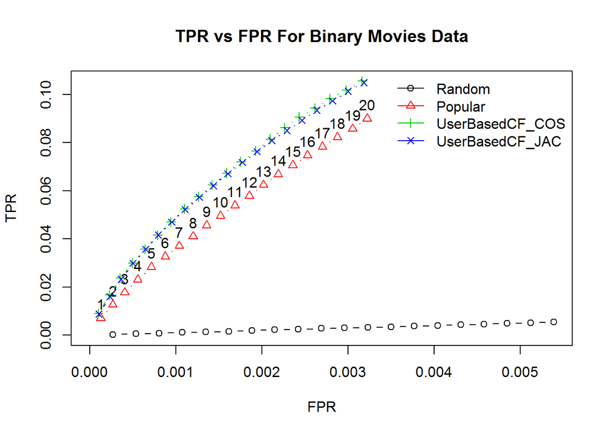

```r
plot(movies_split_eval, annotate = 2, legend = "topright")
title(main = "TPR vs FPR For Binary Movies Data")
```

The graph shows that the user-based collaborative filtering algorithms perform better than the two baseline algorithms, but there is very little to separate these two, with the cosine distance marginally outperforming the Jaccard distance on these data.

Here is the precision recall curve for the binary Movies data:

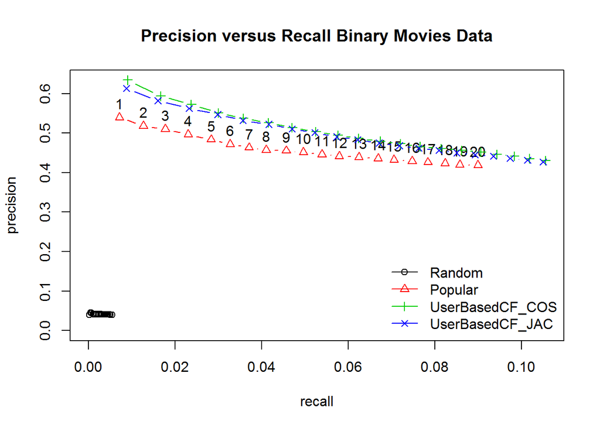

```r
plot(movies_split_eval, "prec/rec", annotate = 2, legend = "bottomright")
title(main = "Precision versus Recall Binary Movies Data")
```

The precision recall curve paints a similar picture, with the user-based collaborative filtering algorithm that uses the cosine distance coming out as the winner. Note that the trade off between precision and recall surfaces in a top-N recommender system via the number of recommendations that the system makes. The way our evaluation scheme works is that we treat users in the test data as new users in the system that just contributed a certain number of ratings. We hold out as many ratings as the given parameter allows. Then, we apply our model in order to see if the ratings we suggest will agree with the ratings that remain. We order our suggestions in descending order of confidence so that in a top-1 recommendation system, we will suggest the item we believe has the best chance of interesting the user. Increasing N therefore is like casting a wider net. We will be less precise in our suggestions but are more likely to find something the user will like.